# Data Analyst Project

Jihan Farah S

2022-10-23

# Cyclistic Bike-Sharing Analysis

## Overview

This project is part of Google Data Analytics Course on Coursera.

In 2016, Cyclistic launched a successful bike-sharing offering. Since then, the program has grown to a fleet of 5,824 bikes that are geo-tracked and locked into a network of 692 stations across Chicago. Bikes can be accessed from one station and returned to another at any time in the system.

To date, Cyclistic’s marketing strategy has relied on efforts to build general awareness and attract a broad consumer segment. One approach that helps make this happen is price flexibility: one-way tickets, full-day passes, and annual memberships. Customers who purchase a one-way ticket or a full day ticket are referred to as casual riders. Customers who purchase an annual membership are Cyclistic members. Therefore, the marketing analyst team needs to better understand the differences between annual members and regular riders in this month.

## Dataset Preview

This dataset is in the form of CSV (comma-separated value) with 701,339 rows of data. The field in data included:

1. ride_id
2. rideable_type
3. started_at
4. ended_at
5. start_station_name
6. start_station_id
7. end_station_name
8. end_station_id
9. start_lat
10. start_lng
11. end_lat
12. end_lng
13. member_casual

## Steps

1. Import data.
2. Clean and add data to prepare for analysis.
3. Perform a descriptive analysis.

## Import Data

```r
library("readr")
library("dplyr")

#Importing data
divvy_202209 <- read_csv("~/divvy-tripdata/202209-divvy-publictripdata.csv")
divvy_202208 <- read_csv("~/divvy-tripdata/202208-divvy-tripdata.csv")
divvy_202207 <- read_csv("~/divvy-tripdata/202207-divvy-tripdata.csv")
divvy_202206 <- read_csv("~/divvy-tripdata/202206-divvy-tripdata.csv")
divvy_202205 <- read_csv("~/divvy-tripdata/202205-divvy-tripdata.csv")
divvy_202204 <- read_csv("~/divvy-tripdata/202204-divvy-tripdata.csv")
divvy_202203 <- read_csv("~/divvy-tripdata/202203-divvy-tripdata.csv")
divvy_202202 <- read_csv("~/divvy-tripdata/202202-divvy-tripdata.csv")
divvy_202201 <- read_csv("~/divvy-tripdata/202201-divvy-tripdata.csv")
divvy_202112 <- read_csv("~/divvy-tripdata/202112-divvy-tripdata.csv")
divvy_202111 <- read_csv("~/divvy-tripdata/202111-divvy-tripdata.csv")
divvy_202110 <- read_csv("~/divvy-tripdata/202110-divvy-tripdata.csv")


#Checking data dimension
dim(divvy_202209)
```

```
## [1] 701339     13
```

```r
dim(divvy_202208)
```

```
## [1] 785932     13
```

```r
dim(divvy_202207)
```

```
## [1] 823488     13
```

```r
dim(divvy_202206)
```

```
## [1] 769204     13
```

```r
dim(divvy_202205)
```

```
## [1] 634858     13
```

```r
dim(divvy_202204)
```

```
## [1] 371249     13
```

```r
dim(divvy_202203)
```

```
## [1] 284042     13
```

```r
dim(divvy_202202)
```

```
## [1] 115609     13
```

```r
dim(divvy_202201)
```

```
## [1] 103770     13
```

```r
dim(divvy_202112)
```

```
## [1] 247540     13
```

```r
dim(divvy_202111)
```

```
## [1] 359978     13
```

```r
dim(divvy_202110)
```

```
## [1] 631226     13
```

```r
#Checking columns names
colnames(divvy_202209)
```

```
##  [1] "ride_id"            "rideable_type"      "started_at"
##  [4] "ended_at"           "start_station_name" "start_station_id"
##  [7] "end_station_name"   "end_station_id"     "start_lat"
## [10] "start_lng"          "end_lat"            "end_lng"
## [13] "member_casual"
```

```r
colnames(divvy_202208)
```

```
##  [1] "ride_id"            "rideable_type"      "started_at"
##  [4] "ended_at"           "start_station_name" "start_station_id"
##  [7] "end_station_name"   "end_station_id"     "start_lat"
## [10] "start_lng"          "end_lat"            "end_lng"
## [13] "member_casual"
```

```r
colnames(divvy_202207)
```

```
##  [1] "ride_id"            "rideable_type"      "started_at"
##  [4] "ended_at"           "start_station_name" "start_station_id"
##  [7] "end_station_name"   "end_station_id"     "start_lat"
## [10] "start_lng"          "end_lat"            "end_lng"
## [13] "member_casual"
```

```r
colnames(divvy_202206)
```

```
##  [1] "ride_id"            "rideable_type"      "started_at"
##  [4] "ended_at"           "start_station_name" "start_station_id"
##  [7] "end_station_name"   "end_station_id"     "start_lat"
## [10] "start_lng"          "end_lat"            "end_lng"
## [13] "member_casual"
```

```r
colnames(divvy_202205)
```

```
##  [1] "ride_id"            "rideable_type"      "started_at"
##  [4] "ended_at"           "start_station_name" "start_station_id"
##  [7] "end_station_name"   "end_station_id"     "start_lat"
## [10] "start_lng"          "end_lat"            "end_lng"
## [13] "member_casual"
```

```r
colnames(divvy_202204)
```

```
##  [1] "ride_id"            "rideable_type"      "started_at"
##  [4] "ended_at"           "start_station_name" "start_station_id"
##  [7] "end_station_name"   "end_station_id"     "start_lat"
## [10] "start_lng"          "end_lat"            "end_lng"
## [13] "member_casual"
```

```r
colnames(divvy_202203)
```

```
##  [1] "ride_id"            "rideable_type"      "started_at"
##  [4] "ended_at"           "start_station_name" "start_station_id"
##  [7] "end_station_name"   "end_station_id"     "start_lat"
## [10] "start_lng"          "end_lat"            "end_lng"
## [13] "member_casual"
```

```r
colnames(divvy_202202)
```

```
##  [1] "ride_id"            "rideable_type"      "started_at"
##  [4] "ended_at"           "start_station_name" "start_station_id"
##  [7] "end_station_name"   "end_station_id"     "start_lat"
## [10] "start_lng"          "end_lat"            "end_lng"
## [13] "member_casual"
```

```r
colnames(divvy_202201)
```

```
##  [1] "ride_id"            "rideable_type"      "started_at"
##  [4] "ended_at"           "start_station_name" "start_station_id"
##  [7] "end_station_name"   "end_station_id"     "start_lat"
## [10] "start_lng"          "end_lat"            "end_lng"
## [13] "member_casual"
```

```r
colnames(divvy_202112)
```

```
##  [1] "ride_id"            "rideable_type"      "started_at"
##  [4] "ended_at"           "start_station_name" "start_station_id"
##  [7] "end_station_name"   "end_station_id"     "start_lat"
## [10] "start_lng"          "end_lat"            "end_lng"
## [13] "member_casual"
```

```r
colnames(divvy_202111)
```

```
##  [1] "ride_id"            "rideable_type"      "started_at"
##  [4] "ended_at"           "start_station_name" "start_station_id"
##  [7] "end_station_name"   "end_station_id"     "start_lat"
## [10] "start_lng"          "end_lat"            "end_lng"
## [13] "member_casual"
```

```r
colnames(divvy_202110)
```

```
##  [1] "ride_id"            "rideable_type"      "started_at"
##  [4] "ended_at"           "start_station_name" "start_station_id"
##  [7] "end_station_name"   "end_station_id"     "start_lat"
## [10] "start_lng"          "end_lat"            "end_lng"
## [13] "member_casual"
```

## Data Merging

Before we start to clean the data, we need to merge all the data into one dataset to make it easier.

```r
#Merging all data
all_data <- bind_rows(divvy_202209, divvy_202208, divvy_202207, divvy_202206, divvy_202205, divvy_202204, divvy_202203, divvy_202202, divvy_202201, divvy_202112, divvy_202111, divvy_202110)

#Checking data dimension
dim(all_data)
```

```
## [1] 5828235      13
```

After we merge all datasets, we get that the data has 5828235 rows and 13 columns.

## Data Cleaning and Preparation

We will analyze the behavior of member and casual users, so we only need ride_id, rideable_type, started_at, ended_at, and member_casual.

```r
#Selecting columns
all_data <- all_data %>%
  select(c(ride_id, rideable_type, started_at,ended_at,member_casual))

head(all_data)
```

```
## # A tibble: 6 × 5
##   ride_id          rideable_type started_at          ended_at            membe…¹
##   <chr>            <chr>         <dttm>              <dttm>              <chr>
## 1 5156990AC19CA285 electric_bike 2022-09-01 08:36:22 2022-09-01 08:39:05 casual
## 2 E12D4A16BF51C274 electric_bike 2022-09-01 17:11:29 2022-09-01 17:14:45 casual
## 3 A02B53CD7DB72DD7 electric_bike 2022-09-01 17:15:50 2022-09-01 17:16:12 casual
## 4 C82E05FEE872DF11 electric_bike 2022-09-01 09:00:28 2022-09-01 09:10:32 casual
## 5 4DEEB4550A266AE1 electric_bike 2022-09-01 07:30:11 2022-09-01 07:32:36 casual
## 6 B1721F8C7C3AC6BF electric_bike 2022-09-01 12:04:25 2022-09-01 12:21:08 casual
## # … with abbreviated variable name ¹member_casual
```

We will analyze the ride length of users, so we will make new column that shows the length of ride in minutes. We will count the difference between start and end time of ride.

```r
#Make new column for ride length
all_data$ride_length <- difftime(all_data$ended_at, all_data$started_at)
all_data$ride_length <- as.double(all_data$ride_length)
```

Then, we remove the row with negative values of ride length.

```r
#Remove the row with negative value of ride length
all_data_v2 <- all_data[!all_data$ride_length<0,]
```

We will analyze bike usage for each day, making new columns for the started day, ended day, and each day in a week.

```r
#Make new column for bike usage in start_date, end_date
all_data_v2$started_date <- as.Date(all_data_v2$started_at)
all_data_v2$ended_date <- as.Date(all_data_v2$ended_at)
all_data_v2$Day_of_week <- format(as.Date(all_data_v2$started_date), "%A")
all_data_v2$Month <- format(as.Date(all_data_v2$started_date), "%B")
```

We will check data summary of ride length to see any outliers.

```r
#Summary of ride length
summary(all_data_v2$ride_length)
```

```
##    Min. 1st Qu.  Median    Mean 3rd Qu.    Max.
##       0     356     629    1176    1131 2442301
```

We get that the minimum ride length is 0 sec, the 1st quantile is 356 secs, the median is 629 secs, the 3rd quantile is 1131 secs, the maximum ride length is 2442301 secs, and the mean is 1176 secs. From the summary, we get the possibilities that the usage of bikes can be more than one day. It can affect our analysis if we want to check the average ride length for each day.

Furthermore, we need to filter the data to analyze the ride that starts and ends on the same day.

```r
#Filtering the data
all_data_v3 <- all_data_v2 %>%
  filter(started_date == ended_date)
```

We check the summary from the new dataset.

```r
#Summary of ride length in new dataset
summary(all_data_v3$ride_length)
```

```
##    Min. 1st Qu.  Median    Mean 3rd Qu.    Max.
##     0.0   355.0   626.0   961.3  1123.0 84509.0
```

## Analyzing Data

We will compare the mean, minimum, maximum, and median of member and casual users in ride length for the same-day trip.

```r
#Compare member and casual user in ride length
mean_data <- aggregate(all_data_v3$ride_length ~ all_data_v3$member_casual, FUN = mean)
min_data <- aggregate(all_data_v3$ride_length ~ all_data_v3$member_casual, FUN = min)
max_data <- aggregate(all_data_v3$ride_length ~ all_data_v3$member_casual, FUN = max)
median_data <- aggregate(all_data_v3$ride_length ~ all_data_v3$member_casual, FUN = median)

mean_data
```

```
##   all_data_v3$member_casual all_data_v3$ride_length
## 1                    casual               1285.6031
## 2                    member                735.6604
```

```r
min_data
```

```
##   all_data_v3$member_casual all_data_v3$ride_length
## 1                    casual                       0
## 2                    member                       0
```

```r
max_data
```

```
##   all_data_v3$member_casual all_data_v3$ride_length
## 1                    casual                   84509
## 2                    member                   69947
```

```r
median_data
```

```
##   all_data_v3$member_casual all_data_v3$ride_length
## 1                    casual                     801
## 2                    member                     532
```

From the data, we can see that the mean ride lengths for the same-day trip are 1285.6031 secs for casual users and 735.6604 for member users.

The minimum ride length for both users is 0 seconds and the maximum ride lengths for casual and member users are 84509 secs and 69947 secs, consecutively.

The median ride length for casual and member users is 801 secs and 532 secs.

Then, we compare the total of members and casual users based on rideable type.

```r
#Compare member and casual user with rideable type
library("janitor")
all_data_v3 %>%
  tabyl(rideable_type,member_casual) %>%
  adorn_totals()
```

```
##  rideable_type  casual  member
##   classic_bike  930711 1793134
##    docked_bike  186999       0
##  electric_bike 1258594 1622597
##          Total 2376304 3415731
```

We can see that there are no member users who use docked bike. The number of member users who use classic bike and electric bike are larger than casual users. We also can see the total of member users is larger than casual users.

Then, we compare the total of member and casual user based on ride length each day and each month.

```r
#Compare member and casual user in ride length each day
aggregate(all_data_v3$ride_length ~ all_data_v3$member_casual + all_data_v3$Day_of_week, FUN =mean)
```

```
##    all_data_v3$member_casual all_data_v3$Day_of_week all_data_v3$ride_length
## 1                     casual                  Friday               1197.4401
## 2                     member                  Friday                721.5283
## 3                     casual                  Monday               1313.9411
## 4                     member                  Monday                712.7514
## 5                     casual                Saturday               1439.2714
## 6                     member                Saturday                819.5850
## 7                     casual                  Sunday               1483.7539
## 8                     member                  Sunday                818.5250
## 9                     casual                Thursday               1131.3061
## 10                    member                Thursday                708.0044
## 11                    casual                 Tuesday               1147.4143
## 12                    member                 Tuesday                698.5669
## 13                    casual               Wednesday               1114.3522
## 14                    member               Wednesday                701.5080
```

```r
#Compare member and casual user in ride length each month
aggregate(all_data_v3$ride_length ~ all_data_v3$member_casual + all_data_v3$Month, FUN =mean)
```

```
##    all_data_v3$member_casual all_data_v3$Month all_data_v3$ride_length
## 1                     casual             April               1318.0061
## 2                     member             April                668.7981
## 3                     casual            August               1240.4946
## 4                     member            August                774.3197
## 5                     casual          December               1024.2297
## 6                     member          December                638.9638
## 7                     casual          February               1109.5114
## 8                     member          February                641.4960
## 9                     casual           January                959.1474
## 10                    member           January                646.1426
## 11                    casual              July               1341.2215
## 12                    member              July                798.4347
## 13                    casual              June               1342.9415
## 14                    member              June                805.6161
## 15                    casual             March               1355.4222
## 16                    member             March                686.1239
## 17                    casual               May               1454.2127
## 18                    member               May                773.2102
## 19                    casual          November               1063.0526
## 20                    member          November                647.2846
## 21                    casual           October               1307.7080
## 22                    member           October                720.8491
## 23                    casual         September               1154.8565
## 24                    member         September                744.7380
```

The days and months in the output are not in order, so we need to rearrange it first.

```r
#Ordering day
all_data_v3$Day_of_week <- ordered(all_data_v3$Day_of_week, levels=c("Monday", "Tuesday", "Wednesday", "Thursday","Friday","Saturday","Sunday"))

#Ordering month
all_data_v3$Month <- ordered(all_data_v3$Month, levels=c("January", "February", "March", "April","May","June","July", "August", "September", "October", "November", "December"))
```

Then we can check the data with new order.

```r
#Compare member and casual user in ride length each day
aggregate(all_data_v3$ride_length ~ all_data_v3$member_casual + all_data_v3$Day_of_week, FUN =mean)
```

```
##    all_data_v3$member_casual all_data_v3$Day_of_week all_data_v3$ride_length
## 1                     casual                  Monday               1313.9411
## 2                     member                  Monday                712.7514
## 3                     casual                 Tuesday               1147.4143
## 4                     member                 Tuesday                698.5669
## 5                     casual               Wednesday               1114.3522
## 6                     member               Wednesday                701.5080
## 7                     casual                Thursday               1131.3061
## 8                     member                Thursday                708.0044
## 9                     casual                  Friday               1197.4401
## 10                    member                  Friday                721.5283
## 11                    casual                Saturday               1439.2714
## 12                    member                Saturday                819.5850
## 13                    casual                  Sunday               1483.7539
## 14                    member                  Sunday                818.5250
```

```r
#Compare member and casual user in ride length each month
aggregate(all_data_v3$ride_length ~ all_data_v3$member_casual + all_data_v3$Month, FUN =mean)
```

```
##    all_data_v3$member_casual all_data_v3$Month all_data_v3$ride_length
## 1                     casual           January                959.1474
## 2                     member           January                646.1426
## 3                     casual          February               1109.5114
## 4                     member          February                641.4960
## 5                     casual             March               1355.4222
## 6                     member             March                686.1239
## 7                     casual             April               1318.0061
## 8                     member             April                668.7981
## 9                     casual               May               1454.2127
## 10                    member               May                773.2102
## 11                    casual              June               1342.9415
## 12                    member              June                805.6161
## 13                    casual              July               1341.2215
## 14                    member              July                798.4347
## 15                    casual            August               1240.4946
## 16                    member            August                774.3197
## 17                    casual         September               1154.8565
## 18                    member         September                744.7380
## 19                    casual           October               1307.7080
## 20                    member           October                720.8491
## 21                    casual          November               1063.0526
## 22                    member          November                647.2846
## 23                    casual          December               1024.2297
## 24                    member          December                638.9638
```

For make the data easier to see, we will make the visualization.

### Daily usage

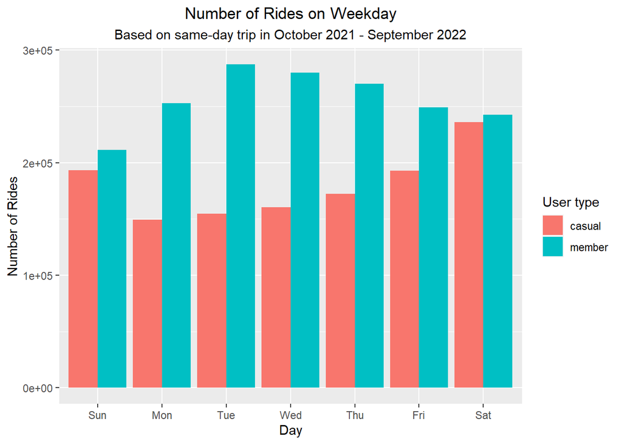

```r
library("ggplot2")
library("lubridate")

#Analyze number of rides on weekday by user type
all_data_v3 %>%
  mutate(weekday = lubridate::wday(started_date, label = TRUE)) %>%  #creates weekday field using wday()
  group_by(member_casual, weekday, rideable_type) %>%  #groups by usertype and weekday'
  summarise(number_of_rides = n(), #calculates the number of rides and average duration
            average_duration = mean(ride_length)) %>% # calculates the average duration
  arrange(member_casual, weekday) %>% # sorts
  ggplot(aes(x = weekday, y = number_of_rides, fill = member_casual)) +
  geom_col(position = "dodge") +
  labs(title = "Number of Rides on Weekday", subtitle = "Based on same-day trip in October 2021 - September 2022", x="Day", y="Number of Rides", fill="User type") +
  theme(plot.title =element_text(hjust = 0.5), plot.subtitle =element_text(hjust = 0.5) )
```

From the graphic, we can see that the number of rides for member users is higher than casual users.

The highest number of rides by member users is on Tuesday, and the highest number of rides by casual users is on Saturday.

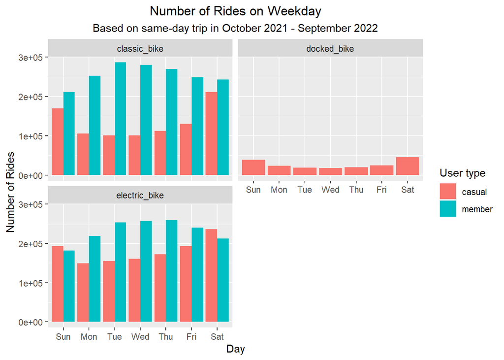

```r
#Analyze number of rides on weekday by user type and bike type
all_data_v3 %>%
  mutate(weekday = lubridate::wday(started_date, label = TRUE)) %>%  #creates weekday field using wday()
  group_by(member_casual, weekday, rideable_type) %>%  #groups by usertype and weekday'
  summarise(number_of_rides = n(), #calculates the number of rides and average duration
            average_duration = mean(ride_length)) %>% # calculates the average duration
  arrange(member_casual, weekday) %>% # sorts
  ggplot(aes(x = weekday, y = number_of_rides, fill = member_casual)) +
  geom_col(position = "dodge") +
  labs(title = "Number of Rides on Weekday", subtitle = "Based on same-day trip in October 2021 - September 2022", x="Day", y="Number of Rides", fill="User type") +
  theme(plot.title =element_text(hjust = 0.5),plot.subtitle = element_text(hjust = 0.5)) +
  facet_wrap("rideable_type",ncol=2,nrow =2)
```

The highest number of rides by casual users with the docked bike is on Saturday.

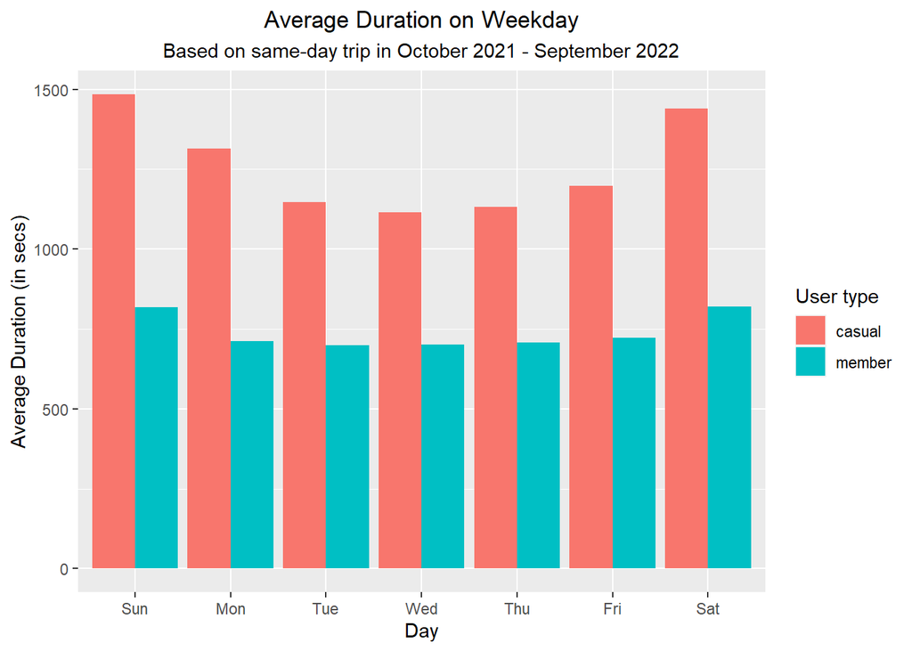

```r
#Analyze average duration on weekday by user type
all_data_v3 %>%
  mutate(weekday = lubridate::wday(started_date, label = TRUE)) %>%  #creates weekday field using wday()
  group_by(member_casual, weekday) %>%  #groups by usertype and weekday'
  summarise(number_of_rides = n(), #calculates the number of rides and average duration
            average_duration = mean(ride_length)) %>% # calculates the average duration
  arrange(member_casual, weekday) %>% # sorts
  ggplot(aes(x = weekday, y = average_duration, fill = member_casual)) +
  geom_col(position = "dodge") +
  labs(title = "Average Duration on Weekday",subtitle = "Based on same-day trip in October 2021 - September 2022", x="Day", y="Average Duration (in secs)", fill="User type") +
  theme(plot.title = element_text(hjust = 0.5), plot.subtitle = element_text(hjust = 0.5))
```

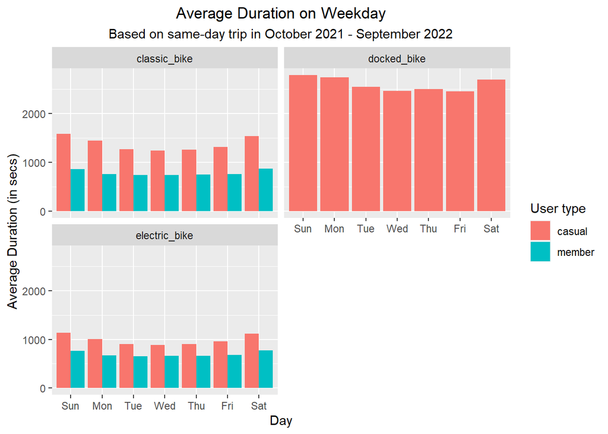

```r
#Analyze average duration on weekday by user type
all_data_v3 %>%
  mutate(weekday = lubridate::wday(started_date, label = TRUE)) %>%  #creates weekday field using wday()
  group_by(member_casual, weekday, rideable_type) %>%  #groups by usertype and weekday'
  summarise(number_of_rides = n(), #calculates the number of rides and average duration
            average_duration = mean(ride_length)) %>% # calculates the average duration
  arrange(member_casual, weekday) %>% # sorts
  ggplot(aes(x = weekday, y = average_duration, fill = member_casual)) +
  geom_col(position = "dodge") +
  labs(title = "Average Duration on Weekday",subtitle = "Based on same-day trip in October 2021 - September 2022", x="Day", y="Average Duration (in secs)", fill="User type") +
  theme(plot.title =element_text(hjust = 0.5), plot.subtitle = element_text(hjust = 0.5)) +
  facet_wrap("rideable_type",ncol=2,nrow =2)
```

We can see the average trip duration of the docked bike are higher than other types of bikes, with the highest being on Sunday.

For the classic bike, the highest trip average duration are by casual users on Saturday and Sunday. Then, the highest trip average duration for the classic bike by member users are also on Saturday and Sunday.

For the electric bike, the highest trip average duration are by casual users on Saturday and Sunday. Then, the highest trip average duration for the electric bike by member users are on Saturday and Sunday.

### Monthly number rides

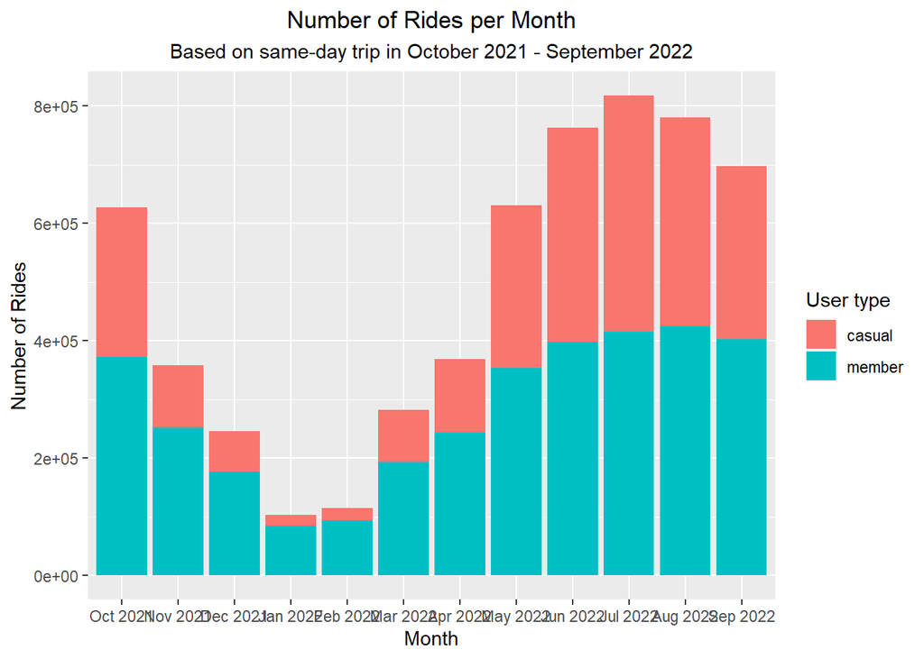

```r
library("ggplot2")
library("lubridate")
library("zoo")
#Analyze number of rides on weekday by user type
all_data_v3 %>%
  mutate(month_name = as.yearmon(started_date, "%m/%Y")) %>%  #creates month field using yearmon
  group_by(member_casual, month_name, rideable_type) %>%  #groups by usertype and weekday'
  summarise(number_of_rides = n(), #calculates the number of rides and average duration
            average_duration = mean(ride_length)) %>% # calculates the average duration
  arrange(member_casual, month_name) %>% # sorts
  ggplot(aes(x = factor(month_name), y = number_of_rides, fill = member_casual)) +
  geom_bar(position = "stack", stat="identity") +
  labs(title = "Number of Rides per Month", subtitle = "Based on same-day trip in October 2021 - September 2022", x="Month", y="Number of Rides", fill="User type") +
  theme(plot.title =element_text(hjust = 0.5), plot.subtitle =element_text(hjust = 0.5) )
```

## Conclusion and recommendation

From the analysis that we did, we get that:

1. The number of rides by member users is more than by casual users, with the highest number of rides by member users on the weekdays and the highest number of rides by casual users on the weekend.
2. The average duration of the trip by casual users is more than member users, with the highest average duration for users with the docked bike.
3. The number of rides per month is related to the season. For summer, the number of rides increases, and for winter the number of rides decreases.

From the conclusions, we can make some recommendations, such as:

1. Make special offers for member users on the weekend. Based on the data, the highest number of rides by casual users is on the weekend. With this offering, we may gain new member users.
2. Make a seasonal members system. Based on the data, we have some months with a high number of rides and others are low. With this, we may still gain new customers, and it is more beneficial for the users too.
3. Make special offers for member users who want to extend the membership period. It may keep them as member users and new member users interested.